# M2_891_20251_PEC3_Jsolanm

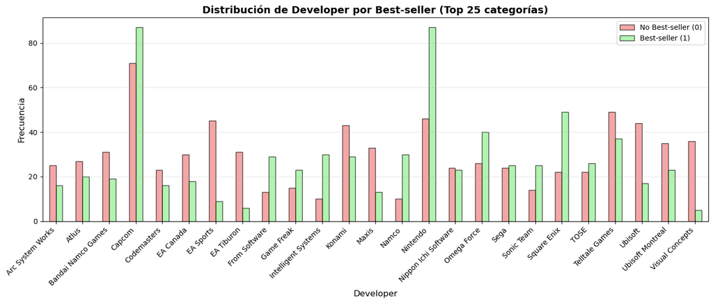

```
Estadísticas de Developer
Total de categorías únicas: 2596
Top 5 categorías más frecuentes:
Developer
Capcom            158
Nintendo          133
Telltale Games     86
Konami             72
Square Enix        71
Name: count, dtype: int64
```

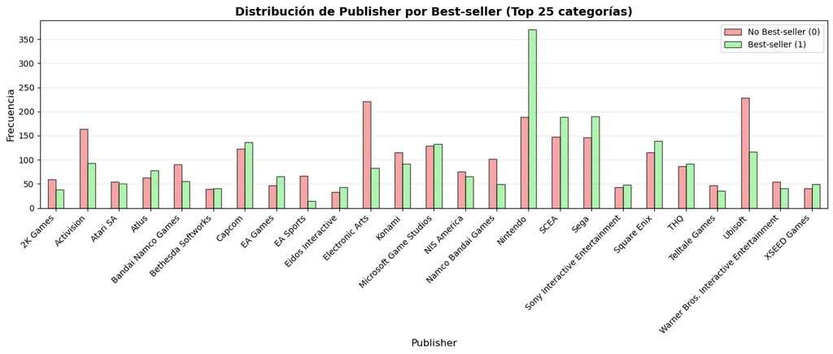

```
Estadísticas de Publisher
Total de categorías únicas: 1182
Top 5 categorías más frecuentes:
Publisher
Nintendo           558
Ubisoft            346
SCEA               336
Sega               336
Electronic Arts    304
Name: count, dtype: int64
```

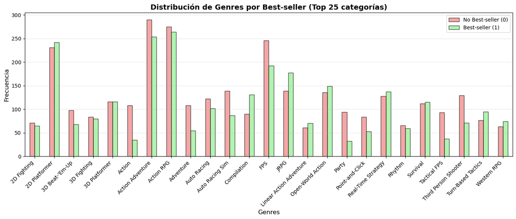

```
Estadísticas de Genres
Total de categorías únicas: 117
Top 5 categorías más frecuentes:
Genres
Action Adventure    544
Action RPG          539
2D Platformer       473
FPS                 438
JRPG                316
Name: count, dtype: int64
```

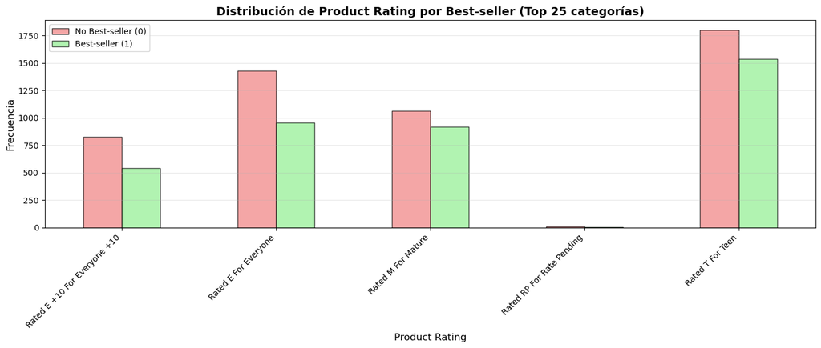

```
Estadísticas de Product Rating
Total de categorías únicas: 5
Top 5 categorías más frecuentes:
Product Rating
Rated T For Teen                3333
Rated E For Everyone            2389
Rated M For Mature              1979
Rated E +10 For Everyone +10    1369
Rated RP For Rate Pending         15
Name: count, dtype: int64
```

```python
# 3. Análisis de variables categóricas

# Identificamos variables categóricas
categorical_columns = data.select_dtypes(include=['object']).columns.tolist()

# Creamos histogramas para cada variable categórica
for col in categorical_columns:
    # Obtenemos las categorías más frecuentes (top 25 para evitar gráficos muy grandes)
    top_categories = data[col].value_counts().head(25).index

    # Filtramos datos solo con top categorías
    data_filtered = data[data[col].isin(top_categories)]

    # Creamos tabla de frecuencias cruzadas
    cross_tab = pd.crosstab(data_filtered[col], data_filtered['Best-seller'])

    # Gráfico
    fig, ax = plt.subplots(figsize=(14, 6))
    cross_tab.plot(kind='bar',
                   ax=ax,
                   color=['lightcoral', 'lightgreen'],
                   edgecolor='black',
                   alpha=0.7)

    ax.set_title(f'Distribución de {col} por Best-seller (Top 25 categorías)',
                 fontsize=14, fontweight='bold')
    ax.set_xlabel(col, fontsize=12)
    ax.set_ylabel('Frecuencia', fontsize=12)
    ax.legend(['No Best-seller (0)', 'Best-seller (1)'], loc='best')
    ax.grid(True, alpha=0.3, axis='y')

    plt.xticks(rotation=45, ha='right')
    plt.tight_layout()
    plt.show()

    # Mostrar estadísticas
    print(f"\nEstadísticas de {col}")
    print(f"Total de categorías únicas: {data[col].nunique()}")
    print(f"Top 5 categorías más frecuentes:")
    print(data[col].value_counts().head())
```

**Análisis:**

1. Evalúa la relación de las frecuencias de la variable `Best-seller`. Reflexiona sobre cómo se distribuyen los valores de la clase objetivo. ¿Es la distribución significativamente desigual? ¿Qué implica esto para el análisis y la modelización de los datos?
2. Analiza la información proporcionada por los histogramas de las variables descriptoras. Observa si hay diferencias notables en las distribuciones de estas variables entre las clases. Pregúntate: ¿Hay variables que muestren patrones distintos en función de si el juego es un éxito de ventas?
3. Considera si hay otras formas de visualización que podrían ser útiles para entender mejor los datos. Por ejemplo, ¿serían útiles los diagramas de caja (boxplots) para visualizar la distribución de las variables en ambas clases? ¿Podría un mapa de calor de la matriz de correlación entre variables ayudarte a entender las relaciones entre ellas?

Este análisis te ayudará a obtener una comprensión más profunda de la naturaleza de tus datos y a identificar posibles características que podrían ser importantes para identificar los futuros blockbusters.

**Respuesta:**

### 1.

Está muy igualado, un 56% de no best-seller frente a un 44% que si. Lo normal sería esto, no todos los juegos que se sacan tienen que ser éxitos, quizas me hubiera esperado más porcentaje en no best-seller, es posible también que los datos estén un poco manchados al coger videojuegos medianamente famosos, hay muchos juegos que se lanzan que no llegan a nada, quizas pueda ensuciarnos un poco el modelo final pero puede ser una buena aproximación.